# Using celda with RNASeq: TBD Analysis

## 2.1.3 Exploratory Data Analysis with Multiple Cell/Gene Clusters

Using the `celda` function, we can create a `celda_list` object that will contain all of the combinations of K/L parameters at each Gibbs sampling chain.

```r
celda.multiple.k <- celda(counts = sim_counts$counts,K = 2:4, L = 9:11, nchains = 3, max.iter = 10, model = "celda_CG")
```

```
## Starting celda...
```

Using the `visualize_model_performance` function, we can visualize various performance metrics as a function of K / L to aid parameter choice.

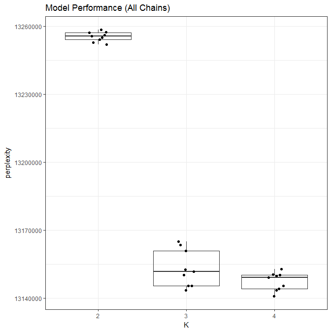

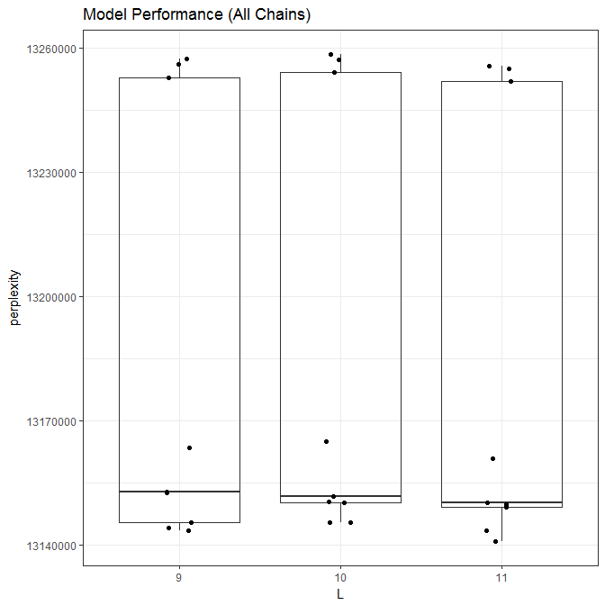

```r
visualize_model_performance(celda.multiple.k,method="perplexity")
```

Since K = 4 seems to yield the lowest perplexity, we can run the following:

```r
celda.multiple.l <- celda(counts = sim_counts$counts,K = 4, L = 9:11, nchains = 3, max.iter = 10, model = "celda_CG")
```

```
## Starting celda...
```

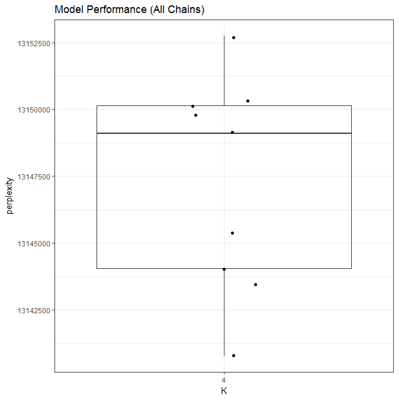

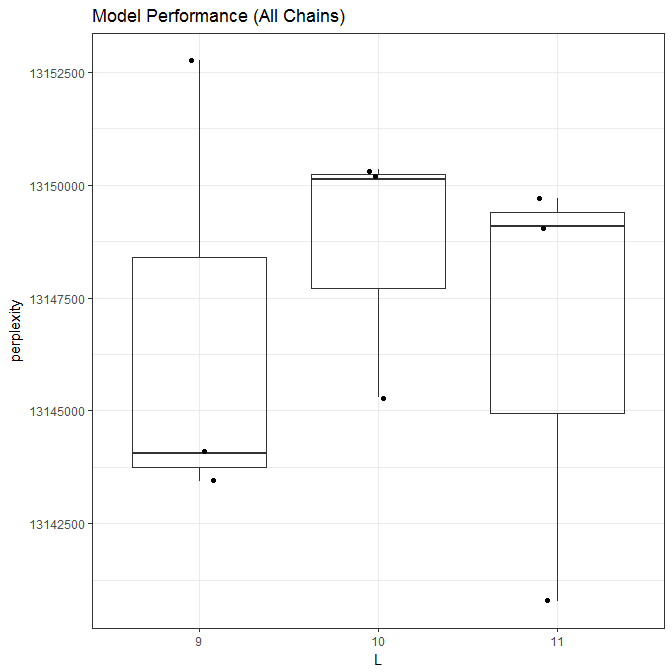

```r
visualize_model_performance(celda.multiple.l,method="perplexity")
```

In which we seem to get the lowest perplexity at L = 9.

To determine how the cells/genes would cluster at these values, you can use the function `getModel`

```r
getModel(celda.multiple.l, K= 4,L=9)
```

[output not shown]

[output cut: 69 more lines]

[output not shown]

# 3. PBMC Analysis with celda

```r
### Read Data
cmatp<-(readRDS("../data/cmatp"))
cmatp_select <- cmatp[as.vector(tcrossprod(matrix(rep(1.0,2700),1,2700),cmatp>0))>500,]
```

```
## Note: method with signature 'matrix#Matrix' chosen for function 'tcrossprod',
##  target signature 'matrix#lgTMatrix'.
##  "ANY#TsparseMatrix" would also be valid
```

### Initial Visualization

[figure not shown]

```r
pheatmap(scale(log(as.matrix(cmatp_select+1)),center = F),cluster_rows = FALSE, cluster_cols = FALSE)
```

### 3.1.1 Cellular clustering

```r
toy_celda_cg = celda(as.matrix(cmatp_select), model="celda_CG",K = 15,L=20)
```

```
## Starting celda...
```

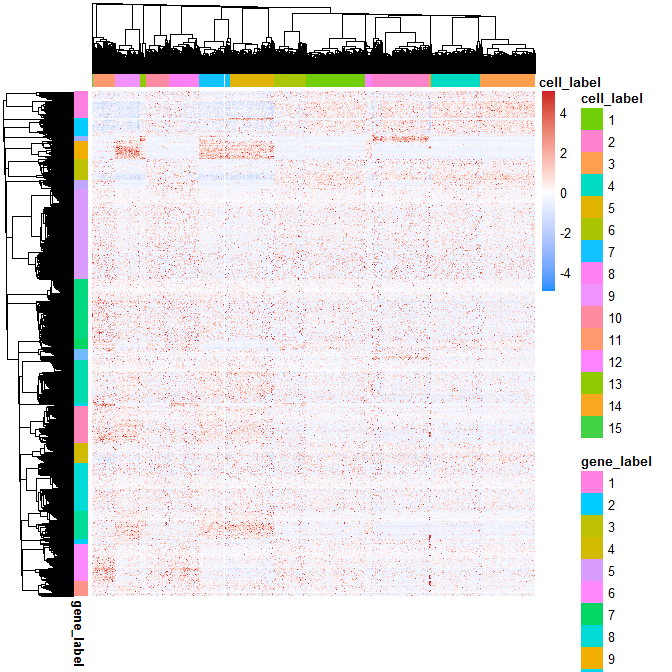

```r
a= as.matrix(cmatp_select)

render_celda_heatmap(counts =t(t(a)/colSums(a)), z = toy_celda_cg$res.list[[1]]$z,
                     y = toy_celda_cg$res.list[[1]]$y,
                     z.trim=c(-5,5),scale.row = TRUE)
```